# Exploratory factor analysis (practical)

Note updated January 17, 2024

Wan Nor Arifin (wnarifin@usm.my), Biostatistics and Research Methodology Unit, Universiti Sains Malaysia Website: wnarifin.github.io

This work is licensed under a [Creative Commons Attribution-ShareAlike 4.0 International License](http://creativecommons.org/licenses/by-sa/4.0/).

# 1 Practical

In this practical session, we are going to explore the validity of a new questionnaire of attitude towards statistics by exploratory factor analysis and obtain the internal consistency reliability.

We will focus on:

- The number of extracted factors
- Factor loadings
- Factor correlations
- Cronbach’s alpha

# 2 Preliminaries

## 2.1 Load libraries

Our analysis will require installing `psych` (Revelle, 2023) and `lattice` (Sarkar, 2023) packages. Make sure you already installed all of them. Load the libraries,

```r
library(foreign)  # for importing SPSS data
library(psych)  # for psychometrics
library(lattice)  # easy to plot multivariate plots
```

## 2.2 Load data set

Download data set “Attitude_Statistics v3.sav”. View the original questionnaire “Attitude_Statistics v3 Questions.pdf”.

Read the data set as `data` and view the basic information.

```r
data = read.spss("Attitude_Statistics v3.sav", use.value.labels = F, to.data.frame = T)
str(data)
```

```
'data.frame':   150 obs. of  13 variables:
 $ ID : num  1 2 3 4 5 6 8 9 10 11 ...
 $ Q1 : num  2 3 5 2 4 4 4 3 4 2 ...
  ..- attr(*, "value.labels")= Named num [1:5] 5 4 3 2 1
  .. ..- attr(*, "names")= chr [1:5] "STRONGLY AGREE" "AGREE" "NEUTRAL" "DISAGREE" ...
 $ Q2 : num  3 2 4 2 1 4 2 4 2 5 ...
  ..- attr(*, "value.labels")= Named num [1:5] 5 4 3 2 1
  .. ..- attr(*, "names")= chr [1:5] "STRONGLY AGREE" "AGREE" "NEUTRAL" "DISAGREE" ...
 $ Q3 : num  3 3 5 2 4 4 5 3 3 2 ...
  ..- attr(*, "value.labels")= Named num [1:5] 5 4 3 2 1
  .. ..- attr(*, "names")= chr [1:5] "STRONGLY AGREE" "AGREE" "NEUTRAL" "DISAGREE" ...
 $ Q4 : num  3 3 1 4 2 3 3 2 4 4 ...
  ..- attr(*, "value.labels")= Named num [1:5] 5 4 3 2 1
  .. ..- attr(*, "names")= chr [1:5] "STRONGLY AGREE" "AGREE" "NEUTRAL" "DISAGREE" ...
 $ Q5 : num  4 4 1 3 5 4 4 3 3 4 ...
  ..- attr(*, "value.labels")= Named num [1:5] 5 4 3 2 1
  .. ..- attr(*, "names")= chr [1:5] "STRONGLY AGREE" "AGREE" "NEUTRAL" "DISAGREE" ...
 $ Q6 : num  4 4 1 2 1 4 3 3 4 5 ...
  ..- attr(*, "value.labels")= Named num [1:5] 5 4 3 2 1
  .. ..- attr(*, "names")= chr [1:5] "STRONGLY AGREE" "AGREE" "NEUTRAL" "DISAGREE" ...
 $ Q7 : num  3 4 1 2 4 4 4 2 3 4 ...
  ..- attr(*, "value.labels")= Named num [1:5] 5 4 3 2 1
  .. ..- attr(*, "names")= chr [1:5] "STRONGLY AGREE" "AGREE" "NEUTRAL" "DISAGREE" ...
 $ Q8 : num  3 3 4 2 5 3 3 3 3 4 ...
  ..- attr(*, "value.labels")= Named num [1:5] 5 4 3 2 1
  .. ..- attr(*, "names")= chr [1:5] "STRONGLY AGREE" "AGREE" "NEUTRAL" "DISAGREE" ...
 $ Q9 : num  3 3 4 2 5 4 3 4 5 4 ...
  ..- attr(*, "value.labels")= Named num [1:5] 5 4 3 2 1
  .. ..- attr(*, "names")= chr [1:5] "STRONGLY AGREE" "AGREE" "NEUTRAL" "DISAGREE" ...
 $ Q10: num  3 3 5 2 3 4 3 4 4 4 ...
  ..- attr(*, "value.labels")= Named num [1:5] 5 4 3 2 1
  .. ..- attr(*, "names")= chr [1:5] "STRONGLY AGREE" "AGREE" "NEUTRAL" "DISAGREE" ...
 $ Q11: num  4 4 1 3 4 4 3 3 4 4 ...
  ..- attr(*, "value.labels")= Named num [1:5] 5 4 3 2 1
  .. ..- attr(*, "names")= chr [1:5] "STRONGLY AGREE" "AGREE" "NEUTRAL" "DISAGREE" ...
 $ Q12: num  2 2 4 3 4 4 3 3 3 2 ...
  ..- attr(*, "value.labels")= Named num [1:5] 5 4 3 2 1
  .. ..- attr(*, "names")= chr [1:5] "STRONGLY AGREE" "AGREE" "NEUTRAL" "DISAGREE" ...
 - attr(*, "variable.labels")= Named chr [1:13] "Participant's ID" "I love all analysis." "I dream of normal distribution." "I think of probability in life." ...
  ..- attr(*, "names")= chr [1:13] "ID" "Q1" "Q2" "Q3" ...
 - attr(*, "codepage")= int 65001
```

```r
names(data)  # list variable names
```

```
 [1] "ID"  "Q1"  "Q2"  "Q3"  "Q4"  "Q5"  "Q6"  "Q7"  "Q8"  "Q9"  "Q10" "Q11" "Q12"
```

```r
head(data)  # the first 6 observations
```

```
  ID Q1 Q2 Q3 Q4 Q5 Q6 Q7 Q8 Q9 Q10 Q11 Q12
1  1  2  3  3  3  4  4  3  3  3   3   4   2
2  2  3  2  3  3  4  4  4  3  3   3   4   2
3  3  5  4  5  1  1  1  1  4  4   5   1   4
4  4  2  2  2  4  3  2  2  2  2   2   3   3
5  5  4  1  4  2  5  1  4  5  5   3   4   4
6  6  4  4  4  3  4  4  4  3  4   4   4   4
```

# 3 Exploratory factor analysis

## 3.1 Preliminary steps

**Clean data**

Replace `data` again after removing `ID` variable. This will make our analysis easier to code.

```r
data = data[-1]  # exclude ID, we are not going to use the variable
str(data)  # 12 variables
```

```
'data.frame':   150 obs. of  12 variables:
 $ Q1 : num  2 3 5 2 4 4 4 3 4 2 ...
  ..- attr(*, "value.labels")= Named num [1:5] 5 4 3 2 1
  .. ..- attr(*, "names")= chr [1:5] "STRONGLY AGREE" "AGREE" "NEUTRAL" "DISAGREE" ...
 $ Q2 : num  3 2 4 2 1 4 2 4 2 5 ...
  ..- attr(*, "value.labels")= Named num [1:5] 5 4 3 2 1
  .. ..- attr(*, "names")= chr [1:5] "STRONGLY AGREE" "AGREE" "NEUTRAL" "DISAGREE" ...
 $ Q3 : num  3 3 5 2 4 4 5 3 3 2 ...
  ..- attr(*, "value.labels")= Named num [1:5] 5 4 3 2 1
  .. ..- attr(*, "names")= chr [1:5] "STRONGLY AGREE" "AGREE" "NEUTRAL" "DISAGREE" ...
 $ Q4 : num  3 3 1 4 2 3 3 2 4 4 ...
  ..- attr(*, "value.labels")= Named num [1:5] 5 4 3 2 1
  .. ..- attr(*, "names")= chr [1:5] "STRONGLY AGREE" "AGREE" "NEUTRAL" "DISAGREE" ...
 $ Q5 : num  4 4 1 3 5 4 4 3 3 4 ...
  ..- attr(*, "value.labels")= Named num [1:5] 5 4 3 2 1
  .. ..- attr(*, "names")= chr [1:5] "STRONGLY AGREE" "AGREE" "NEUTRAL" "DISAGREE" ...
 $ Q6 : num  4 4 1 2 1 4 3 3 4 5 ...
  ..- attr(*, "value.labels")= Named num [1:5] 5 4 3 2 1
  .. ..- attr(*, "names")= chr [1:5] "STRONGLY AGREE" "AGREE" "NEUTRAL" "DISAGREE" ...
 $ Q7 : num  3 4 1 2 4 4 4 2 3 4 ...
  ..- attr(*, "value.labels")= Named num [1:5] 5 4 3 2 1
  .. ..- attr(*, "names")= chr [1:5] "STRONGLY AGREE" "AGREE" "NEUTRAL" "DISAGREE" ...
 $ Q8 : num  3 3 4 2 5 3 3 3 3 4 ...
  ..- attr(*, "value.labels")= Named num [1:5] 5 4 3 2 1
  .. ..- attr(*, "names")= chr [1:5] "STRONGLY AGREE" "AGREE" "NEUTRAL" "DISAGREE" ...
 $ Q9 : num  3 3 4 2 5 4 3 4 5 4 ...
  ..- attr(*, "value.labels")= Named num [1:5] 5 4 3 2 1
  .. ..- attr(*, "names")= chr [1:5] "STRONGLY AGREE" "AGREE" "NEUTRAL" "DISAGREE" ...
 $ Q10: num  3 3 5 2 3 4 3 4 4 4 ...
  ..- attr(*, "value.labels")= Named num [1:5] 5 4 3 2 1
  .. ..- attr(*, "names")= chr [1:5] "STRONGLY AGREE" "AGREE" "NEUTRAL" "DISAGREE" ...
 $ Q11: num  4 4 1 3 4 4 3 3 4 4 ...
  ..- attr(*, "value.labels")= Named num [1:5] 5 4 3 2 1
  .. ..- attr(*, "names")= chr [1:5] "STRONGLY AGREE" "AGREE" "NEUTRAL" "DISAGREE" ...
 $ Q12: num  2 2 4 3 4 4 3 3 3 2 ...
  ..- attr(*, "value.labels")= Named num [1:5] 5 4 3 2 1
  .. ..- attr(*, "names")= chr [1:5] "STRONGLY AGREE" "AGREE" "NEUTRAL" "DISAGREE" ...
```

```r
names(data)  # list variable names
```

```
 [1] "Q1"  "Q2"  "Q3"  "Q4"  "Q5"  "Q6"  "Q7"  "Q8"  "Q9"  "Q10" "Q11" "Q12"
```

```r
head(data)  # the first 6 observations
```

```
  Q1 Q2 Q3 Q4 Q5 Q6 Q7 Q8 Q9 Q10 Q11 Q12
1  2  3  3  3  4  4  3  3  3   3   4   2
2  3  2  3  3  4  4  4  3  3   3   4   2
3  5  4  5  1  1  1  1  4  4   5   1   4
4  2  2  2  4  3  2  2  2  2   2   3   3
5  4  1  4  2  5  1  4  5  5   3   4   4
6  4  4  4  3  4  4  4  3  4   4   4   4
```

**Descriptive statistics**

Check minimum/maximum values per item, and screen for missing values,

```r
describe(data)
```

```
    vars   n mean   sd median trimmed  mad min max range  skew kurtosis   se
Q1     1 150 3.13 1.10      3    3.12 1.48   1   5     4 -0.10    -0.73 0.09
Q2     2 150 3.51 1.03      3    3.55 1.48   1   5     4 -0.14    -0.47 0.08
Q3     3 150 3.18 1.03      3    3.17 1.48   1   5     4 -0.03    -0.42 0.08
Q4     4 150 2.81 1.17      3    2.78 1.48   1   5     4  0.19    -0.81 0.10
Q5     5 150 3.31 1.01      3    3.32 1.48   1   5     4 -0.22    -0.48 0.08
Q6     6 150 3.05 1.09      3    3.05 1.48   1   5     4 -0.04    -0.71 0.09
Q7     7 150 2.92 1.19      3    2.92 1.48   1   5     4 -0.04    -1.06 0.10
Q8     8 150 3.33 1.00      3    3.34 1.48   1   5     4 -0.08    -0.12 0.08
Q9     9 150 3.44 1.05      3    3.48 1.48   1   5     4 -0.21    -0.32 0.09
Q10   10 150 3.31 1.10      3    3.36 1.48   1   5     4 -0.22    -0.39 0.09
Q11   11 150 3.35 0.94      3    3.37 1.48   1   5     4 -0.31    -0.33 0.08
Q12   12 150 2.83 0.98      3    2.83 1.48   1   5     4  0.09    -0.68 0.08
```

Note that all *n* = 150, no missing values. `min`–`max` cover the whole range of response options.

% of response to options per item,

```r
response.frequencies(data)
```

```
        1     2    3    4     5 miss
Q1  0.073 0.220 0.32 0.28 0.107    0
Q2  0.033 0.093 0.42 0.24 0.213    0
Q3  0.053 0.180 0.41 0.24 0.113    0
Q4  0.140 0.280 0.30 0.19 0.093    0
Q5  0.040 0.167 0.35 0.33 0.113    0
Q6  0.080 0.233 0.33 0.26 0.093    0
Q7  0.133 0.267 0.23 0.29 0.080    0
Q8  0.047 0.100 0.48 0.23 0.147    0
Q9  0.047 0.093 0.42 0.25 0.187    0
Q10 0.073 0.107 0.42 0.23 0.167    0
Q11 0.027 0.153 0.35 0.39 0.087    0
Q12 0.073 0.327 0.33 0.23 0.033    0
```

All response options are used with no missing values.

**Normality of data**

This is done to check for the normality of the data. If the data are normally distributed, we may use maximum likelihood (ML) for the EFA, which will allow more detailed analysis. Otherwise, the extraction method of choice is **principal axis factoring (PAF)**, because it does not require normally distributed data (Brown, 2015).

*Univariate normality*

1. Histograms

Prepare the list of variable we want to copy-paste in `histogram()`,

```r
cat(names(data), sep = " + ")
```

```
Q1 + Q2 + Q3 + Q4 + Q5 + Q6 + Q7 + Q8 + Q9 + Q10 + Q11 + Q12
```

Plot the histograms,

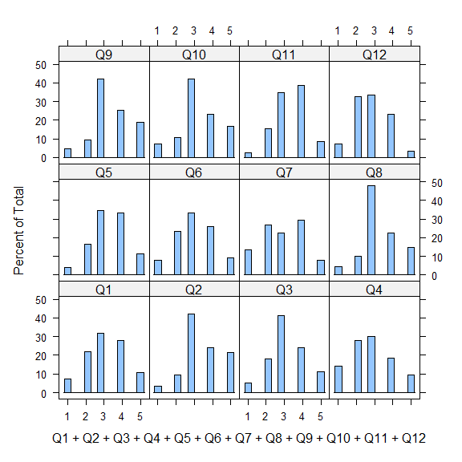

```r
histogram(~ Q1 + Q2 + Q3 + Q4 + Q5 + Q6 + Q7 + Q8 + Q9 + Q10 + Q11 + Q12,
          data = data)
# graphically looks normal
```

all of which look quite normal.

2. Shapiro Wilk’s test

```r
mapply(shapiro.test, data)
```

```
          Q1                            Q2
statistic 0.9153467                     0.8832131
p.value   1.075493e-07                  1.656343e-09
method    "Shapiro-Wilk normality test" "Shapiro-Wilk normality test"
data.name "dots[[1L]][[1L]]"            "dots[[1L]][[2L]]"
          Q3                            Q4
statistic 0.9078453                     0.9134687
p.value   3.76009e-08                   8.22525e-08
method    "Shapiro-Wilk normality test" "Shapiro-Wilk normality test"
data.name "dots[[1L]][[3L]]"            "dots[[1L]][[4L]]"
          Q5                            Q6
statistic 0.9061485                     0.9161874
p.value   2.985958e-08                  1.21404e-07
method    "Shapiro-Wilk normality test" "Shapiro-Wilk normality test"
data.name "dots[[1L]][[5L]]"            "dots[[1L]][[6L]]"
          Q7                            Q8
statistic 0.9055861                     0.8811527
p.value   2.767883e-08                  1.300764e-09
method    "Shapiro-Wilk normality test" "Shapiro-Wilk normality test"
data.name "dots[[1L]][[7L]]"            "dots[[1L]][[8L]]"
          Q9                            Q10
statistic 0.8893183                     0.8957393
p.value   3.445127e-09                  7.653311e-09
method    "Shapiro-Wilk normality test" "Shapiro-Wilk normality test"
data.name "dots[[1L]][[9L]]"            "dots[[1L]][[10L]]"
          Q11                           Q12
statistic 0.8919437                     0.9009719
p.value   4.75751e-09                   1.500687e-08
method    "Shapiro-Wilk normality test" "Shapiro-Wilk normality test"
data.name "dots[[1L]][[11L]]"           "dots[[1L]][[12L]]"
```

all *P*-values < 0.05, i.e. not normal.

*Multivariate normality*

To say the data are multivariate normal:

- *z*-kurtosis < 5 (Bentler, 2006) and the *P*-value should be $\geq$ 0.05.
- The plot should also form a straight line (Arifin, 2015).

Run Mardia’s multivariate normality test,

```r
mardia(data)
```

```
Call: mardia(x = data)

Mardia tests of multivariate skew and kurtosis
Use describe(x) the to get univariate tests
n.obs = 150   num.vars =  12
b1p =  29.4   skew =  735.01  with probability  <=  2.7e-27
 small sample skew =  752.01  with probability <=  3.4e-29
b2p =  200.33   kurtosis =  10.8  with probability <=  0
```

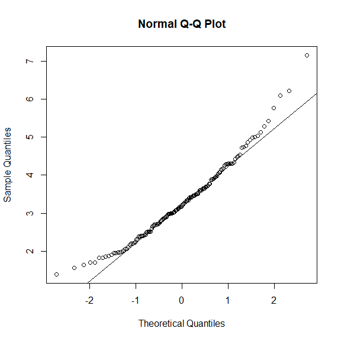

In our case, `kurtosis` = 10.8 (*P* < 0.05). At the start and the end, the dots are away from the line. Thus, the data are not normally distributed at multivariate level. Our extraction method PAF can deal with this non-normality.

## 3.2 Step 1

**Check suitability of data for analysis**

1. Kaiser-Meyer-Olkin (KMO) Measure of Sampling Adequacy (MSA)

MSA is a relative measure of the amount of correlation (Kaiser, 1970). It indicates whether it is worthwhile to analyze a correlation matrix or not. KMO is an overall measure of MSA for a set of items. The following is the guideline in interpreting KMO values (Kaiser & Rice, 1974):

| Value | Interpretation |
| --- | --- |
| < 0.5 | Unacceptable |
| 0.5 – 0.59 | Miserable |
| 0.6 – 0.69 | Mediocre |
| 0.7 – 0.79 | Middling |
| 0.8 – 0.89 | Meritorious |
| 0.9 – 1.00 | Marvelous |

KMO of our data,

```r
KMO(data)
```

```
Kaiser-Meyer-Olkin factor adequacy
Call: KMO(r = data)
Overall MSA =  0.76
MSA for each item =
  Q1   Q2   Q3   Q4   Q5   Q6   Q7   Q8   Q9  Q10  Q11  Q12
0.34 0.83 0.64 0.75 0.83 0.81 0.82 0.81 0.68 0.70 0.82 0.68
```

KMO = 0.76, i.e. middling. In general, > 0.7 is acceptable.

2. Bartlet’s test of sphericity

Basically it tests whether the correlation matrix is an identity matrix[^1] (Bartlett, 1951; Gorsuch, 2014).

A significant test indicates worthwhile correlations between the items (i.e. off-diagonal values are not 0).

Test our data,

```r
cortest.bartlett(data)
```

```
R was not square, finding R from data
```

```
$chisq
[1] 562.3065

$p.value
[1] 7.851736e-80

$df
[1] 66
```

*P*-value < 0.05, significant. Items are correlated.

**Determine the number of factors**

There are several ways in determining the number of factors, among them are (Courtney, 2013):

1. Kaiser’s eigenvalue > 1 rule.
2. Cattell’s scree test.
3. Parallel analysis.
4. Very simple structure (VSS).
5. Velicer’s minimum average partial (MAP).

The details:

1. Kaiser’s eigenvalue > 1 rule.

Factors with eigenvalues > 1 are retained. Eigenvalue can be interpreted as the proportion of the information in a factor. The cut-off of 1 means the factor contains information = 1 item. Thus it is not worthwhile keeping factor with information < 1 item.

2. Cattell’s scree test.

“Scree” is a collection of loose stones at the base of a hill. This test is based on eye-ball judgement of an eigenvalues vs number of factors plot. Look for the number of eigenvalue points/factors before we reach the “scree”, i.e. at the elbow of the plot.

Obtain the eigenvalues and scree plot,

```
Scree of eigen values
Call: NULL
Eigen values of factors  [1]  2.67  1.78  0.18  0.07  0.02 -0.05 -0.09 -0.15 -0.20 -0.41 -0.46 -0.70
Eigen values of Principal Components [1] 3.29 2.66 1.04 0.96 0.79 0.73 0.65 0.52 0.46 0.36 0.33 0.22
```

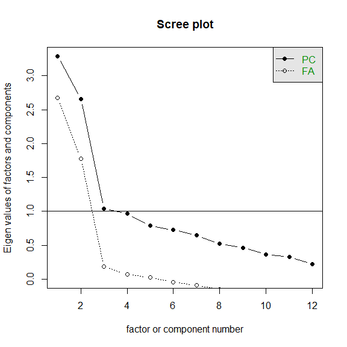

```r
scree = scree(data)
print(scree)
```

Eigen values of factors > 1 = 2, and 2 dots (i.e. for –o– FA) are above the Eigen values = 1 horizontal line. Thus, based on our judgement on the scree plot and eigenvalues (of factor analysis), the suitable number of factors = 2.

3. Parallel analysis.

The scree plot based on the data is compared to the scree plot based on the randomly generated data (Brown, 2015). The number of factors is the number of points above the intersection between the plots.

```r
parallel = fa.parallel(data, fm = "pa", fa = "fa")
```

```
Parallel analysis suggests that the number of factors =  2  and the number of components =  NA
```

```r
print(parallel)
```

```
Call: fa.parallel(x = data, fm = "pa", fa = "fa")
Parallel analysis suggests that the number of factors =  2  and the number of components =  NA

 Eigen Values of

 eigen values of factors
 [1]  2.67  1.78  0.18  0.07  0.02 -0.05 -0.09 -0.15 -0.20 -0.41 -0.46 -0.70

 eigen values of simulated factors
 [1]  0.65  0.38  0.29  0.20  0.13  0.06  0.00 -0.08 -0.14 -0.22 -0.28 -0.36

 eigen values of components
 [1] 3.29 2.66 1.04 0.96 0.79 0.73 0.65 0.52 0.46 0.36 0.33 0.22

 eigen values of simulated components
[1] NA
```

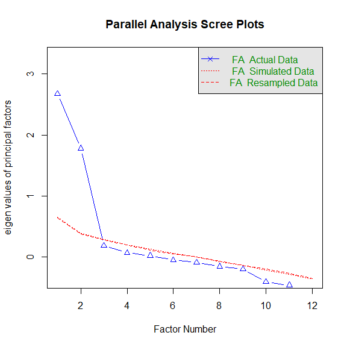

From the parallel-analysis scree plot, there are two dots above the dashed lines. This is suggestive of 2 factors.

4. Very simple structure (VSS) criterion.

VSS compares the original correlation matrix to a simplified correlation matrix (Revelle, 2023). Look for the highest VSS value at complexity 1 (`vss1`) i.e. an item loads only on one factor.

5. Velicer’s minimum average partial (MAP) criterion.

MAP criterion indicates the optimum number of factors that minimizes the MAP value. The procedure extracts the correlations explained by the factors, leaving only minimum correlations unrelated to the factors.

Obtain these two criteria,

```r
vss(data)
```

```
Very Simple Structure
Call: vss(x = data)
Although the VSS complexity 1 shows  5  factors, it is probably more reasonable to think about  3  factors
VSS complexity 2 achieves a maximimum of 0.83  with  7  factors

The Velicer MAP achieves a minimum of 0.03  with  2  factors
BIC achieves a minimum of  -153.21  with  2  factors
Sample Size adjusted BIC achieves a minimum of  -17.12  with  2  factors

Statistics by number of factors
  vss1 vss2   map dof   chisq    prob sqresid  fit RMSEA  BIC SABIC complex  eChisq
1 0.47 0.00 0.065  54 306.874 4.7e-37    11.9 0.47 0.177   36 207.2     1.0 622.420
2 0.68 0.78 0.029  43  62.250 2.9e-02     4.9 0.78 0.054 -153 -17.1     1.3  41.527
3 0.70 0.80 0.048  33  46.613 5.8e-02     4.1 0.82 0.052 -119 -14.3     1.3  25.305
4 0.67 0.80 0.067  24  27.823 2.7e-01     3.7 0.83 0.032  -92 -16.5     1.4  14.039
5 0.72 0.80 0.089  16  19.445 2.5e-01     3.0 0.86 0.037  -61 -10.1     1.3   8.727
6 0.65 0.78 0.119   9   8.585 4.8e-01     2.8 0.87 0.000  -37  -8.0     1.5   3.975
7 0.61 0.83 0.159   3   3.094 3.8e-01     1.9 0.92 0.013  -12  -2.4     1.5   1.281
8 0.62 0.76 0.239  -2   0.082      NA     2.2 0.90    NA   NA    NA     1.6   0.038
    SRMR eCRMS eBIC
1 0.1773 0.196  352
2 0.0458 0.057 -174
3 0.0357 0.051 -140
4 0.0266 0.044 -106
5 0.0210 0.043  -71
6 0.0142 0.038  -41
7 0.0080 0.038  -14
8 0.0014    NA   NA
```

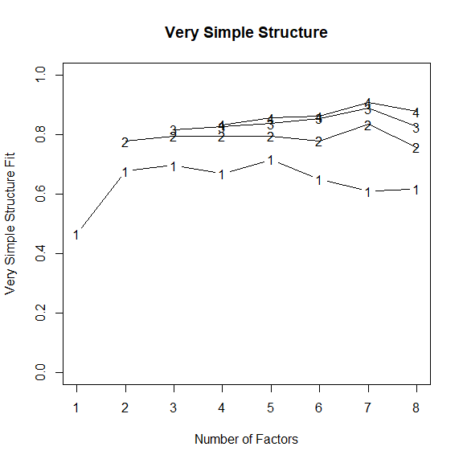

VSS complexity of 1 indicates 3/5 factors (`vss1` largest at 3 and 5 factors), while MAP indicates 2 factors (`map` smallest at 2 factors).

## 3.3 Step 2

**Run EFA**

Our data are not normally distributed, hence the extraction method of choice is **principal axis factoring (PAF)**, because it does not assume normality of data (Brown, 2015). The recommended rotation method is **oblimin** (Fabrigar & Wegener, 2012).

We run EFA by

1. fixing the number of factors as decided from previous step. Two factors are reasonable.
2. choosing an appropriate extraction method. We use PAF, `fm = "pa"`.
3. choosing an appropriate oblique rotation method. We use oblimin, `rotate = "oblimin"`.

```r
fa = fa(data, nfactors = 2, fm = "pa", rotate = "oblimin")
print(fa, cut = .3, digits = 3)  # cut = .3 to view only FLs > 0.3
```

```
Factor Analysis using method =  pa
Call: fa(r = data, nfactors = 2, rotate = "oblimin", fm = "pa")
Standardized loadings (pattern matrix) based upon correlation matrix
       PA1    PA2      h2    u2  com
Q1                0.00366 0.996 1.77
Q2          0.413 0.20708 0.793 1.29
Q3  -0.339  0.439 0.28192 0.718 1.88
Q4   0.813        0.65855 0.341 1.00
Q5   0.584        0.41688 0.583 1.30
Q6   0.725        0.52512 0.475 1.00
Q7   0.732        0.53270 0.467 1.01
Q8          0.655 0.50124 0.499 1.22
Q9          0.773 0.59830 0.402 1.00
Q10         0.883 0.77491 0.225 1.01
Q11  0.528        0.29771 0.702 1.07
Q12 -0.326        0.17665 0.823 1.98

                        PA1   PA2
SS loadings           2.646 2.329
Proportion Var        0.220 0.194
Cumulative Var        0.220 0.415
Proportion Explained  0.532 0.468
Cumulative Proportion 0.532 1.000

 With factor correlations of
      PA1   PA2
PA1 1.000 0.087
PA2 0.087 1.000

Mean item complexity =  1.3
Test of the hypothesis that 2 factors are sufficient.

df null model =  66  with the objective function =  3.9 with Chi Square =  562.306
df of  the model are 43  and the objective function was  0.436

The root mean square of the residuals (RMSR) is  0.046
The df corrected root mean square of the residuals is  0.057

The harmonic n.obs is  150 with the empirical chi square  41.529  with prob <  0.535
The total n.obs was  150  with Likelihood Chi Square =  62.265  with prob <  0.0288

Tucker Lewis Index of factoring reliability =  0.9398
RMSEA index =  0.0542  and the 90 % confidence intervals are  0.0184 0.0832
BIC =  -153.192
Fit based upon off diagonal values = 0.973
Measures of factor score adequacy
                                                    PA1   PA2
Correlation of (regression) scores with factors   0.921 0.930
Multiple R square of scores with factors          0.849 0.865
Minimum correlation of possible factor scores     0.698 0.731
```

```r
print(fa, digits = 3)  # view all FLs
```

```
Factor Analysis using method =  pa
Call: fa(r = data, nfactors = 2, rotate = "oblimin", fm = "pa")
Standardized loadings (pattern matrix) based upon correlation matrix
       PA1    PA2      h2    u2  com
Q1  -0.036  0.052 0.00366 0.996 1.77
Q2   0.159  0.413 0.20708 0.793 1.29
Q3  -0.339  0.439 0.28192 0.718 1.88
Q4   0.813 -0.024 0.65855 0.341 1.00
Q5   0.584  0.229 0.41688 0.583 1.30
Q6   0.725 -0.005 0.52512 0.475 1.00
Q7   0.732 -0.048 0.53270 0.467 1.01
Q8   0.217  0.655 0.50124 0.499 1.22
Q9   0.010  0.773 0.59830 0.402 1.00
Q10 -0.058  0.883 0.77491 0.225 1.01
Q11  0.528  0.097 0.29771 0.702 1.07
Q12 -0.326  0.295 0.17665 0.823 1.98

                        PA1   PA2
SS loadings           2.646 2.329
Proportion Var        0.220 0.194
Cumulative Var        0.220 0.415
Proportion Explained  0.532 0.468
Cumulative Proportion 0.532 1.000

 With factor correlations of
      PA1   PA2
PA1 1.000 0.087
PA2 0.087 1.000

Mean item complexity =  1.3
Test of the hypothesis that 2 factors are sufficient.

df null model =  66  with the objective function =  3.9 with Chi Square =  562.306
df of  the model are 43  and the objective function was  0.436

The root mean square of the residuals (RMSR) is  0.046
The df corrected root mean square of the residuals is  0.057

The harmonic n.obs is  150 with the empirical chi square  41.529  with prob <  0.535
The total n.obs was  150  with Likelihood Chi Square =  62.265  with prob <  0.0288

Tucker Lewis Index of factoring reliability =  0.9398
RMSEA index =  0.0542  and the 90 % confidence intervals are  0.0184 0.0832
BIC =  -153.192
Fit based upon off diagonal values = 0.973
Measures of factor score adequacy
                                                    PA1   PA2
Correlation of (regression) scores with factors   0.921 0.930
Multiple R square of scores with factors          0.849 0.865
Minimum correlation of possible factor scores     0.698 0.731
```

**Results**

Judge the quality of items.

We must looks at

1. Factor loadings (FLs).
2. Communalities (h2).
3. Cross-loading (FLs) and complexity (com).
4. Factor correlations.
1. Factor loadings (pattern coefficients).

Factor loadings (FLs) / pattern coefficients are partial correlation coefficients of factors to items. FLs can be interpreted as follows (Hair, Black, Babin, & Anderson, 2010):

| Value | Interpretation |
| --- | --- |
| 0.3 to 0.4 | Minimally acceptable |
| $\geq$ 0.5 | Practically significant |
| $\geq$ 0.7 | Well-defined structure |

The FLs are interpreted based on absolute values, ignoring the +/- signs. We may need to remove items based on this assessment. Usually we may remove items with FLs < 0.3 (or < 0.4, or < 0.5). But the decision depends on whether we want to set a strict or lenient cut-off value.

*In our output*[^2]:

```
Factor Analysis using method =  pa
Call: fa(r = data, nfactors = 2, rotate = "oblimin", fm = "pa")
Standardized loadings (pattern matrix) based upon correlation matrix
       PA1    PA2      h2    u2  com
Q1                0.00366 0.996 1.77
Q2          0.413 0.20708 0.793 1.29
Q3  -0.339  0.439 0.28192 0.718 1.88
Q4   0.813        0.65855 0.341 1.00
Q5   0.584        0.41688 0.583 1.30
Q6   0.725        0.52512 0.475 1.00
Q7   0.732        0.53270 0.467 1.01
Q8          0.655 0.50124 0.499 1.22
Q9          0.773 0.59830 0.402 1.00
Q10         0.883 0.77491 0.225 1.01
Q11  0.528        0.29771 0.702 1.07
Q12 -0.326        0.17665 0.823 1.98
```

Low FLs? Q1 < .3, Q12 < .4, Q2 & Q3 < .5

Also check for item cross-loading across factors (run the command again as `print(fa, digits = 3)` without `cut = .3`). A cross-loading is when an item has $\geq$ 2 significant loading (i.e. > .3/.4/.5) It indicates the item is not specific to a factor, thus should be removed. The cross-loading can also be judged based on item complexity (`com`). An item specific to a factor should have an item complexity close to one (Pettersson & Turkheimer, 2010).

*In our output*:

```
Factor Analysis using method =  pa
Call: fa(r = data, nfactors = 2, rotate = "oblimin", fm = "pa")
Standardized loadings (pattern matrix) based upon correlation matrix
       PA1    PA2      h2    u2  com
Q1  -0.036  0.052 0.00366 0.996 1.77
Q2   0.159  0.413 0.20708 0.793 1.29
Q3  -0.339  0.439 0.28192 0.718 1.88
Q4   0.813 -0.024 0.65855 0.341 1.00
Q5   0.584  0.229 0.41688 0.583 1.30
Q6   0.725 -0.005 0.52512 0.475 1.00
Q7   0.732 -0.048 0.53270 0.467 1.01
Q8   0.217  0.655 0.50124 0.499 1.22
Q9   0.010  0.773 0.59830 0.402 1.00
Q10 -0.058  0.883 0.77491 0.225 1.01
Q11  0.528  0.097 0.29771 0.702 1.07
Q12 -0.326  0.295 0.17665 0.823 1.98
```

Cross-loadings? Q3 and Q12, indicated by relatively high FLs across factors and high complexity, close to 2.

2. Communalities (`h2`).

An item communality[^3] (IC) is the % of item variance explained by the extracted factors (i.e. by both `PA1` and `PA2` here). It may be considered as $R^2$ in linear regression.

The cut-off value of what is considered acceptable depends on the researcher; it depends on the amount of explained variance that is acceptable to him/her.

A cut-off of 0.5 is practical (Hair et al., 2010), i.e. 50% of item variance is explained by all extracted factors. However, in my practice, it depends on the minimum FL I am willing to accept. Because
$$Item \:variance \:(approximately) = FL^2$$
as if FL = 0 for other factors.

For practical purpose, > 0.25 is acceptable whenever I consider FL > 0.5 as acceptable (because communality = $0.5^2$ = 0.25).

*In our output*:

```
Factor Analysis using method =  pa
Call: fa(r = data, nfactors = 2, rotate = "oblimin", fm = "pa")
Standardized loadings (pattern matrix) based upon correlation matrix
       PA1    PA2      h2    u2  com
Q1                0.00366 0.996 1.77
Q2          0.413 0.20708 0.793 1.29
Q3  -0.339  0.439 0.28192 0.718 1.88
Q4   0.813        0.65855 0.341 1.00
Q5   0.584        0.41688 0.583 1.30
Q6   0.725        0.52512 0.475 1.00
Q7   0.732        0.53270 0.467 1.01
Q8          0.655 0.50124 0.499 1.22
Q9          0.773 0.59830 0.402 1.00
Q10         0.883 0.77491 0.225 1.01
Q11  0.528        0.29771 0.702 1.07
Q12 -0.326        0.17665 0.823 1.98
```

Low communalities? Q1 < Q12 < Q2 < .25 (.004 / .177 / .207 respectively)

3. Factor correlations.

In general, correlations of < 0.85 between factors are expectable in health sciences. If the correlations are > 0.85, the factors are not distinct from each other (factor overlap, or *multicollinearity*), thus they can be combined (Brown, 2015). In EFA context, this can be done by reducing the number of extracted factors.

*In our output*:

```
 With factor correlations of
      PA1   PA2
PA1 1.000 0.087
PA2 0.087 1.000
```

PA1 $\leftrightarrow$ PA2 = .087 < .85

## 3.4 Step 3

In Step 2, we found a number of poor quality items. These must be removed from the item pool.

**Repeat**

Repeat **Step 2** every time an item is removed. Make sure that you remove only **ONE** item at each repeat analysis. Make decisions based on the results.

**Stop**

We may stop once we have

- satisfactory number of factors.
- satisfactory item quality.

We proceed as follows,

Remove Q1? Low communality, low FL.

```r
fa1 = fa(subset(data, select = -Q1), nfactors = 2, fm = "pa", rotate = "oblimin")
print(fa1, cut = .3, digits = 3)
```

```
Factor Analysis using method =  pa
Call: fa(r = subset(data, select = -Q1), nfactors = 2, rotate = "oblimin",
    fm = "pa")
Standardized loadings (pattern matrix) based upon correlation matrix
       PA1    PA2    h2    u2  com
Q2          0.412 0.207 0.793 1.29
Q3  -0.337  0.438 0.280 0.720 1.88
Q4   0.813        0.658 0.342 1.00
Q5   0.584        0.417 0.583 1.30
Q6   0.726        0.526 0.474 1.00
Q7   0.733        0.534 0.466 1.01
Q8          0.653 0.499 0.501 1.22
Q9          0.774 0.601 0.399 1.00
Q10         0.886 0.779 0.221 1.01
Q11  0.529        0.298 0.702 1.07
Q12 -0.325        0.175 0.825 1.98

                        PA1   PA2
SS loadings           2.645 2.327
Proportion Var        0.240 0.212
Cumulative Var        0.240 0.452
Proportion Explained  0.532 0.468
Cumulative Proportion 0.532 1.000

 With factor correlations of
      PA1   PA2
PA1 1.000 0.086
PA2 0.086 1.000
```

Remove Q12? Low communality, (relatively) low FL, high complexity (cross loading).

```r
fa2 = fa(subset(data, select = -c(Q1, Q12)), nfactors = 2, fm = "pa", rotate = "oblimin")
print(fa2, cut = .3, digits = 3)
```

```
Factor Analysis using method =  pa
Call: fa(r = subset(data, select = -c(Q1, Q12)), nfactors = 2, rotate = "oblimin",
    fm = "pa")
Standardized loadings (pattern matrix) based upon correlation matrix
       PA1    PA2    h2    u2  com
Q2          0.420 0.211 0.789 1.24
Q3  -0.313  0.409 0.239 0.761 1.87
Q4   0.841        0.702 0.298 1.01
Q5   0.595        0.426 0.574 1.26
Q6   0.707        0.501 0.499 1.00
Q7   0.732        0.531 0.469 1.01
Q8          0.661 0.507 0.493 1.19
Q9          0.780 0.608 0.392 1.00
Q10         0.892 0.789 0.211 1.01
Q11  0.529        0.298 0.702 1.06

                        PA1   PA2
SS loadings           2.554 2.256
Proportion Var        0.255 0.226
Cumulative Var        0.255 0.481
Proportion Explained  0.531 0.469
Cumulative Proportion 0.531 1.000

 With factor correlations of
    PA1 PA2
PA1 1.0 0.1
PA2 0.1 1.0
```

Remove Q3? Low communality, (relatively) low FL, high complexity (cross loading).

```r
fa3 = fa(subset(data, select = -c(Q1, Q12, Q3)), nfactors = 2, fm = "pa", rotate = "oblimin")
print(fa3, cut = .3, digits = 3)
```

```
Factor Analysis using method =  pa
Call: fa(r = subset(data, select = -c(Q1, Q12, Q3)), nfactors = 2,
    rotate = "oblimin", fm = "pa")
Standardized loadings (pattern matrix) based upon correlation matrix
       PA1    PA2    h2    u2  com
Q2          0.404 0.202 0.798 1.27
Q4   0.816        0.660 0.340 1.00
Q5   0.606        0.435 0.565 1.20
Q6   0.706        0.497 0.503 1.00
Q7   0.749        0.551 0.449 1.02
Q8          0.669 0.518 0.482 1.16
Q9          0.822 0.670 0.330 1.00
Q10         0.863 0.733 0.267 1.01
Q11  0.533        0.301 0.699 1.05

                        PA1   PA2
SS loadings           2.463 2.104
Proportion Var        0.274 0.234
Cumulative Var        0.274 0.507
Proportion Explained  0.539 0.461
Cumulative Proportion 0.539 1.000

 With factor correlations of
      PA1   PA2
PA1 1.000 0.133
PA2 0.133 1.000
```

Remove Q2? Low communality, (relatively) low FL.

```r
fa4 = fa(subset(data, select = -c(Q1, Q12, Q3, Q2)), nfactors = 2, fm = "pa", rotate = "oblimin")
print(fa4, cut = .3, digits = 3)
```

```
Factor Analysis using method =  pa
Call: fa(r = subset(data, select = -c(Q1, Q12, Q3, Q2)), nfactors = 2,
    rotate = "oblimin", fm = "pa")
Standardized loadings (pattern matrix) based upon correlation matrix
       PA1    PA2    h2    u2  com
Q4   0.818        0.664 0.336 1.00
Q5   0.614        0.447 0.553 1.21
Q6   0.704        0.494 0.506 1.00
Q7   0.747        0.549 0.451 1.02
Q8          0.634 0.471 0.529 1.19
Q9          0.849 0.717 0.283 1.00
Q10         0.861 0.733 0.267 1.01
Q11  0.533        0.299 0.701 1.04

                        PA1   PA2
SS loadings           2.441 1.933
Proportion Var        0.305 0.242
Cumulative Var        0.305 0.547
Proportion Explained  0.558 0.442
Cumulative Proportion 0.558 1.000

 With factor correlations of
      PA1   PA2
PA1 1.000 0.121
PA2 0.121 1.000
```

We are now satisfied with the item quality (at FL > 0.5) and factor correlation. Please also note the `Proportion Var` row; the values indicate the amount of variance explained by each factor (i.e. remember $R^2$ multiple linear regression?). **PA1** explains 30.5%, and **PA2** explains 24.2% of the variance in the items. In total, the extracted factors explain 54.7% of the variance.

## 3.5 Summary

> **PA1**: Q4, Q5, Q6, Q7, Q11

> **PA2**: Q8, Q9, Q10

Name the factor based on the content of the remaining items/factor (look at the PDF file/printed copy of the questionnaire).

> **PA1**: Affinity

> **PA2**: Importance

# 4 Internal consistency reliability

**Cronbach’s alpha**

Next, we want to determine the internal consistency reliability of the factors extracted in the EFA. This will be done by Cronbach’s alpha. We determine the reliability of each factor separately by including the selected items per factor.

We group the items in `PA1` and `PA2` factors into R objects.

```r
PA1 = c("Q4","Q5","Q6","Q7","Q11")
PA2 = c("Q8","Q9","Q10")
```

We can now analyze by the subsets of `data`.

In the results, we specifically look for:

1. Cronbach’s alpha

The Cronbach’s alpha indicates the internal consistency reliability. The interpretation is detailed as follows (DeVellis, 2012, pp. 95–96):

| Value | Interpretation |
| --- | --- |
| <0.6 | Unacceptable |
| 0.60 to 0.65 | Undesirable |
| 0.65 to 0.70 | Minimally acceptable |
| 0.70 to 0.80 | Respectable |
| 0.8 to 0.9 | Very good |
| >.90 | Consider shortening the scale (i.e. multicollinear[^4]). |

In the output, look for the line below `lower alpha upper 95% confidence boundaries` line. This line displays the Cronbach’s alpha with its lower and upper 95% CI.

2. Corrected item-total correlation

There are four item-total correlations provided in `psych` under `Item statistics` header in the output. We consider these two:

- `r.cor` = Item-total correlation, corrected for item overlap (Revelle, 2023). This is recommended by Revelle (2023).
- `r.drop` = Corrected item-total correlation, i.e. the correlation between the item with total WITHOUT the item. This is reported in SPSS.

Ideally must be > 0.5 (Hair et al., 2010)

3. Cronbach’s alpha if item deleted

`raw_alpha` under `Reliability if an item is dropped:` heading is the Cronbach’s alpha if the item is deleted.

This indicates the effect of removing the item on the Cronbach’s alpha. If there is a marked improvement in Cronbach’s alpha, removing the item is justified. Keep the item whenever it results in a reduction in the alpha, or the improvement is very minimal.

**PA1**

```r
alpha.pa1 = alpha(data[PA1])
print(alpha.pa1, digits = 3)
```

```
Reliability analysis
Call: alpha(x = data[PA1])

  raw_alpha std.alpha G6(smc) average_r  S/N    ase mean    sd median_r
     0.817     0.815   0.791     0.469 4.41 0.0231 3.09 0.824    0.449

    95% confidence boundaries
         lower alpha upper
Feldt    0.766 0.817 0.859
Duhachek 0.771 0.817 0.862

 Reliability if an item is dropped:
    raw_alpha std.alpha G6(smc) average_r  S/N alpha se   var.r med.r
Q4      0.748     0.748   0.704     0.426 2.97   0.0332 0.00638 0.414
Q5      0.792     0.788   0.749     0.482 3.72   0.0268 0.01323 0.503
Q6      0.776     0.776   0.736     0.464 3.46   0.0292 0.00747 0.449
Q7      0.771     0.771   0.726     0.457 3.36   0.0299 0.00593 0.449
Q11     0.810     0.809   0.768     0.514 4.22   0.0249 0.00700 0.537

 Item statistics
      n raw.r std.r r.cor r.drop mean    sd
Q4  150 0.836 0.825 0.782  0.709 2.81 1.172
Q5  150 0.723 0.737 0.635  0.569 3.31 1.011
Q6  150 0.772 0.765 0.687  0.624 3.05 1.092
Q7  150 0.795 0.777 0.710  0.640 2.92 1.190
Q11 150 0.660 0.687 0.557  0.500 3.35 0.935

Non missing response frequency for each item
        1     2     3     4     5 miss
Q4  0.140 0.280 0.300 0.187 0.093    0
Q5  0.040 0.167 0.347 0.333 0.113    0
Q6  0.080 0.233 0.333 0.260 0.093    0
Q7  0.133 0.267 0.227 0.293 0.080    0
Q11 0.027 0.153 0.347 0.387 0.087    0
```

Cronbach’s alpha = 0.817 (95% CI: 0.771, 0.862). Corrected item-total correlations (`r_cor`) show all items have good correlation with the total (> 0.5). Cronbach’s alphas if item deleted (`raw_alpha` under `Reliability if an item is dropped`) show removing any of the item does not increase the Cronbach’s alpha.

**PA2**

```r
alpha.pa2 = alpha(data[PA2])
print(alpha.pa2, digits = 3)
```

```
Reliability analysis
Call: alpha(x = data[PA2])

  raw_alpha std.alpha G6(smc) average_r  S/N    ase mean    sd median_r
     0.826     0.825   0.771     0.611 4.71 0.0246 3.36 0.904    0.559

    95% confidence boundaries
         lower alpha upper
Feldt    0.771 0.826 0.869
Duhachek 0.777 0.826 0.874

 Reliability if an item is dropped:
    raw_alpha std.alpha G6(smc) average_r  S/N alpha se var.r med.r
Q8      0.840     0.841   0.725     0.725 5.28   0.0260    NA 0.725
Q9      0.715     0.717   0.559     0.559 2.54   0.0462    NA 0.559
Q10     0.708     0.708   0.548     0.548 2.43   0.0476    NA 0.548

 Item statistics
      n raw.r std.r r.cor r.drop mean   sd
Q8  150 0.807 0.816 0.645  0.596 3.33 1.00
Q9  150 0.882 0.881 0.807  0.726 3.44 1.05
Q10 150 0.892 0.885 0.815  0.732 3.31 1.10

Non missing response frequency for each item
        1     2    3     4     5 miss
Q8  0.047 0.100 0.48 0.227 0.147    0
Q9  0.047 0.093 0.42 0.253 0.187    0
Q10 0.073 0.107 0.42 0.233 0.167    0
```

Cronbach’s alpha = 0.826 (95% CI: 0.777, 0.874). Corrected item-total correlations (`r_cor`) show all items have high correlation with the total (> 0.5). Cronbach’s alphas if item deleted (`raw_alpha` under `Reliability if an item is dropped`) show removing `Q8` causes an increase in Cronbach’s alpha by 0.014 (only!), which is negligible. We want to keep as many items as possible in a factor.

Overall, for both `PA1` and `PA2`,

We may conclude that the factors are reliable and we must keep all items.

# 5 Results presentation

In the report, you must include a number of important statements and results pertaining to the EFA,

1. The extraction and rotation methods.
2. The KMO and Bartlett’s test of sphericity results.
3. The number of extracted factors, based on the applied methods e.g. scree plot, parallel analysis, MAP etc.
4. Details about the cut-off values of the FLs and factor correlations.
5. Details about the repeat EFA, i.e. item removed, reduction/increase in the number of factors etc.
6. The percentage of variance explained (in the final solution).
7. The cut-off value of the Cronbach’s alpha.
8. Summary table, which includes FLs, communalities, Cronbach’s alpha, and factor correlations.

Factor loadings and reliability in the EFA.

| Factor | Item | Factor loading | Cronbach’s $\alpha$ |
| --- | --- | --- | --- |
| Affinity | Q4 | 0.818 | 0.817 |
|  | Q5 | 0.614 |  |
|  | Q6 | 0.704 |  |
|  | Q7 | 0.747 |  |
|  | Q11 | 0.533 |  |
| Importance | Q8 | 0.634 | 0.826 |
|  | Q9 | 0.849 |  |
|  | Q10 | 0.861 |  |

Factor correlation: Affinity $\leftrightarrow$ Importance, *r* = 0.121.

# References

Arifin, W. N. (2015). The graphical assessment of multivariate normality using SPSS. *Education in Medicine Journal*, *7*(2), e71–e75.

Bartlett, M. S. (1951). The effect of standardization on a $\chi$ 2 approximation in factor analysis. *Biometrika*, *38*(3/4), 337–344.

Bentler, P. M. (2006). *EQS 6 structural equations program manual*. Encino, CA: Multivariate Software, Inc.

Brown, T. A. (2015). *Confirmatory factor analysis for applied research*. New York: The Guilford Press.

Courtney, M. G. R. (2013). Determining the number of factors to retain in EFA: Using the SPSS r-menu v2. 0 to make more judicious estimations. *Practical Assessment, Research & Evaluation*, *18*(8), 1–14.

DeVellis, R. F. (2012). *Scale development: Theory and applications (3rd ed)*. California: Sage publications.

Fabrigar, L. R., & Wegener, D. T. (2012). *Exploratory factor analysis*. New York: Oxford University Press.

Gorsuch, R. L. (2014). *Exploratory factor analysis*. New York: Routledge.

Hair, J. F., Black, W. C., Babin, B. J., & Anderson, R. E. (2010). *Multivariate data analysis*. New Jersey: Prentice Hall.

Kaiser, H. F. (1970). A second generation little jiffy. *Psychometrika*, *35*(4), 401–415.

Kaiser, H. F., & Rice, J. (1974). Little jiffy, mark IV. *Educational and Psychological Measurement*, *34*(1), 111–117.

Pettersson, E., & Turkheimer, E. (2010). Item selection, evaluation, and simple structure in personality data. *Journal of Research in Personality*, *44*(4), 407–420.

Revelle, W. (2023). *Psych: Procedures for psychological, psychometric, and personality research*. Retrieved from https://personality-project.org/r/psych/ https://personality-project.org/r/psych-manual.pdf

Sarkar, D. (2023). *Lattice: Trellis graphics for r*. Retrieved from https://lattice.r-forge.r-project.org/

Streiner, D. L. (2003). Starting at the beginning: An introduction to coefficient alpha and internal consistency. *Journal of Personality Assessment*, *80*(1), 99–103.

[^1]: a matrix, for example, in case of three variables:
    $$\begin{array}{c}
    V1\\
    V2\\
    V3
    \end{array}\begin{bmatrix}1 & 0 & 0\\
    0 & 1 & 0\\
    0 & 0 & 1
    \end{bmatrix}$$

    For the calculation of communality for the obliquely-rotated solution, we have to include the factor correlation (FC) (Brown, 2015),
    $$IC = FL_{PA1}^2 + FL_{PA2}^2 + 2(FL_{PA1}
    \times FC \times FL_{PA2})$$

    For example, communality of **Q2** = `.16^2 + .41^2 + 2*.16*.09*.41` = `0.205508` $\approx$ `0.2071` in the output. Use `print(fa)` instead to view the full results.
[^4]: See Streiner (2003).